# 第8回 遺伝子発現データで、教師あり解析を一周する

# 8. 何が言えるか？

## 問いのもう半分

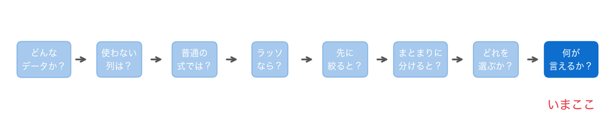

- 当てる式が決まった
- 残るのは、「一緒に動く遺伝子を特定できるか」

## お手本：10本は入れ替わるか

8節 ① 入れ替わる10本●○

```python
chosen = []
for tr_i, te_i in kf.split(X_tr):
    r_i = X_tr.iloc[tr_i].corrwith(y_tr.iloc[tr_i])
    top_i = r_i.abs().sort_values(ascending=False).index[:10]
    chosen.append(set(top_i))
print([len(chosen[0] & c) for c in chosen])
print(len(set.intersection(*chosen)), '本が5回とも選ばれた')
```

- `set`は重なりのない集まり。`&`で、両方に入っているものを取り出す

## 5回とも選ばれたのは0本

8節 ① 入れ替わる10本●●

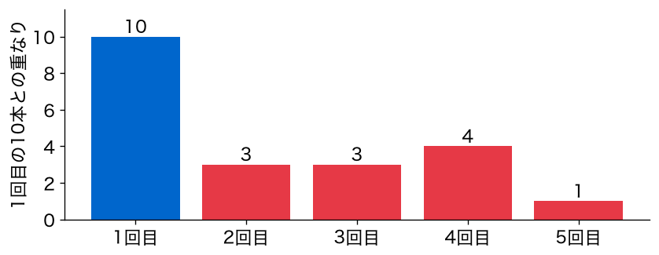

```
0 本が5回とも選ばれた
```

- 1回目の10本と重なるのは、ほかの回では1〜4本だけ

## なぜ入れ替わるのか

8節 ② 入れ替わる理由●○○

- TRIM32と一緒に動く遺伝子は、何百本ものまとまりになっている（6節）
- まとまりの中の遺伝子は互いに似ているので、どれを選んでも当たりは変わらない
- 分け方が変わると、たまたま相関が少し強かった別の遺伝子が選ばれる

## 第4回・第5回と同じこと

8節 ② 入れ替わる理由●●○

- 似た列があると係数が揺れた（第4回）。ラッソは似た列のどちらかを0にした（第5回）
- 同じことが、何百本の規模で起きている

## 代表にすぎない

8節 ② 入れ替わる理由●●●

- 選ばれた10本は「TRIM32を動かしている遺伝子」ではない
- 「一緒に動くまとまりの、その時の代表」にすぎない

## 答え：当てられる

8節 ③ 答え●○○

相関の強い10本を選ぶ手順をパイプラインに入れた式で、テストの30匹のMAEは0.0603。平均で当てた0.0913より34%小さい。ほかの遺伝子から、TRIM32の発現量は当てられる。

## 答え：特定はできない

8節 ③ 答え●●○

選ばれる遺伝子は分け方で入れ替わり、一緒に動く大きなまとまり（答えを見ずに分けた527本、TRIM32と相関0.746）の代表にすぎない。言えるのは「TRIM32は数百本の遺伝子と一緒に動いている」ことまで。

## 答え：手順の注意

8節 ③ 答え●●●

- 答えを使う手順を交差検証の外で行うと、関係のないデータでも当たって見える
- 並べ替えた答えで、先に選ぶと0.0863（平均の0.0954より小さかった）

## まだ言えないこと①：原因か

8節 ④ まだ言えないこと●○○

- 一緒に動くことは、どちらがどちらを動かしているかを教えない
- 確かめるには、遺伝子を働かなくした実験などが要る

## まだ言えないこと②：ほかの組織

8節 ④ まだ言えないこと●●○

- このデータは、ラットの目の組織だけ
- ほかの組織やほかの動物で同じかは、分からない

## まだ言えないこと③：意味

8節 ④ まだ言えないこと●●●

- まとまりの遺伝子が、どんな働きを共有しているか
- 文献やデータベースで調べる必要がある

# まとめ

## 今日の道筋を振り返る

⑥ 振り返る●○○○○○

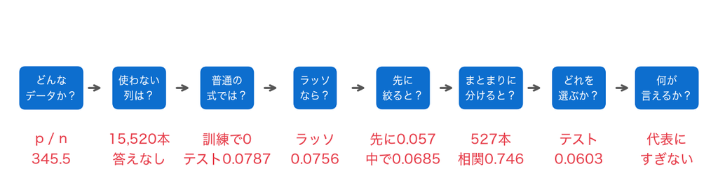

- 8つの小さな問いに答えて、当てられることと、特定できないことを分けた

## 今日の歩み

⑥ 振り返る●●○○○○

使わない列 → 普通の式 → ラッソ → 先に絞る落とし穴 → まとまり → スクリプト → テスト → 解釈

## 今日持ち帰る1文

⑥ 振り返る●●●○○○

遺伝子が匹数より多くても、正則化や絞り込みをパイプラインの中に入れれば、当たりを正しく評価できる。答えを使う手順は、すべて交差検証の中に入れる。当たる式が作れても、効いている遺伝子を1本に特定できるとは限らない。

## 今日の要点①：評価

⑥ 振り返る●●●●○○

- $p > n$では、普通の線形回帰は訓練でぴったり当たるが、当てにならない
- 使わない列は、答えを見ずに、訓練だけで決める
- 列を選ぶのもαを選ぶのも、パイプラインに入れて交差検証する（入れ子）

## 今日の要点②：まとまり

⑥ 振り返る●●●●●○

- 階層的クラスタリング：距離$1 - r$で、近いまとまりから順にまとめる（群平均法）
- 樹形図を切って、まとまりを作る
- 一緒に動く遺伝子は、平均すると雑音が打ち消し合う

## 今日の要点③：スクリプト

⑥ 振り返る●●●●●●

- 手順を関数（`load`・`choose_columns`・`build_pipeline`・`evaluate`）に分ける
- 1本のスクリプトにすると、いつも同じ結果になり、引数を変えるだけで比べ直せる

## 課題の出し方

⑦ このあと●○○○

- ノートの最後の「課題（提出）」に取り組む
- 応用②の答えと応用③の文章を、LACSに入力して提出（＝出席。期限なし）
- AIを使ってもよい。何を聞いて、どう直したかを1行書く

## 次回予告：縮める

⑦ このあと●●○○

- 今日は、2,000本を、まとまりごとの平均で10本ほどの点数に縮めた
- 平均は、いちばん単純な縮め方

## 次回の問い

⑦ このあと●●●○

たくさんの数でできたデータを、できるだけ情報を失わずに、少ない数に縮めるには、どうすればよいか？

## このあと：課題へ

⑦ このあと●●●●

ノートの「課題（提出）」へ。スクリプトの引数`k`を変えて、相関の強い遺伝子の本数を比べ直します。

# ここから先は解答

## 課題のあとで見る

課題（提出）に取り組んでから見てください。動画の人は、ここで一時停止。

## 応用①：kを変える

```python
for k in [5, 20, 50]:
    print(k, evaluate(build_pipeline('top', k=k), X_tr, y_tr))
```

```
5 0.069
20 0.0751
50 0.0941
```

- 関数を呼ぶだけで、3つの候補を比べ直せた

## 応用②：答えはk=5の0.069

- 3つの中で交差検証のMAEがいちばん小さいのは、`k`=5の0.069
- 本編の`k`=10（0.0685）とほぼ同じ。20本、50本と増やすと悪くなる

## 応用③：模範例

相関の強い遺伝子をパイプラインの中で選ぶ式で、TRIM32の発現量を、平均で当てるより3割ほど小さい誤差で当てられました（テストの30匹でMAE 0.0603、平均では0.0913）。ただし、選ばれる遺伝子は分け方で入れ替わり、数百本のまとまりの代表にすぎないので、個々の遺伝子を特定できたとは言えません。次は、まとまりの遺伝子の働きをデータベースで調べることを提案します。

## 書き方の型

- 1文目：当たりの数（テストのMAEと、平均で当てたときとの比較）
- 2文目：選ばれた遺伝子をどこまで信じてよいか
- 3文目：次に何を調べるか

# 発展（任意）

## 同じ病気のほかの遺伝子

- バルデー・ビードル症候群には、ほかにも原因遺伝子が知られている
- Lztfl1・Bbs5・Ttc8・Arl6・Bbs2などが、TRIM32と一緒に動くかを見る

## お手本：5つの遺伝子

```python
bbs = ['Lztfl1', 'Bbs5', 'Ttc8', 'Arl6', 'Bbs2']
probes = genes.index[genes['symbol'].isin(bbs)]
probes = [p for p in probes if p in X_tr.columns]
r_bbs = X_tr[probes].corrwith(y_tr)
print(pd.DataFrame({'遺伝子': genes.loc[probes, 'symbol'],
                    '相関': r_bbs.round(3),
                    '10本に入る': [p in top10 for p in probes],
                    '7番': [groups.get(p) == 7 for p in probes]}))
```

- `isin`は、値が並びのどれかと同じならTrue

## 一緒に動くのに選ばれない

```
               遺伝子     相関  10本に入る     7番
1368509_at    Bbs2  0.621   False  False
1372557_at    Arl6  0.625   False  False
1375894_at  Lztfl1  0.730   False  False
1378416_at    Ttc8  0.667   False  False
1378656_at    Bbs5  0.694   False  False
```

- 相関0.621〜0.73で一緒に動くが、10本にも2,000本にも入らない

## 選ばれない＝関係ない、ではない

- 0.8を超える遺伝子がたくさんあるので、10本には入らない
- 同じ病気の遺伝子が一緒に動くことは、大事な手がかり
- 何を知りたいかで、解析の手順を選ぶ

## 試すなら

- `r.rank(ascending=False)[probes]`で、15,520本の中で何番目に相関が強いかを見る

## まとまりの遺伝子の名前

```python
in7 = groups.index[groups == 7]
r_in7 = X_tr[in7].corrwith(y_tr).sort_values(ascending=False)
print(pd.DataFrame({'遺伝子': genes.loc[r_in7.index[:10], 'symbol'],
                    '相関': r_in7[:10].round(3)}))
```

```
               遺伝子     相関
1383110_at  Klhl24  0.766
1394033_at   Rbbp9  0.761
1377791_at   RragB  0.757
1379029_at   Zfp62  0.753
1383673_at  Nap1l2  0.745
1389584_at     NaN  0.743
1380174_at     NaN  0.743
1386683_at    Atrx  0.736
1379495_at     NaN  0.735
1398308_at    Rpa3  0.718
```

## データの外の知識と合わせる

- まとまりの遺伝子の一覧を、遺伝子の働きのデータベース（Gene Ontologyなど）と照らす
- まとまりの意味は、データの外の知識と合わせて初めて読める

## おわり

- 今日は、3万本の遺伝子からTRIM32を当て、テストのMAEは0.0603だった
- 選ばれる遺伝子は入れ替わり、まとまりの代表にすぎなかった